# Classification of Weight Lifting Exercises

Daigo Tanaka

February 20, 2015

## Introduction

This report <sup>source</sup> describes the steps I took to classify “Weight Lifting Exercise Dataset” generated by Velloso, et al. <sup>Velloso2013</sup> The dataset records the measurements from the sensors attached to the glove, armband, lumbar belt and dumbbell while the participants lift the dumbbell in 5 different ways: One exactly according to the specification and 4 representing the common mistakes.

This classification exercise was done in part to complete Coursera Data Science Specialization track. Given a training dataset, the goal is to generate a machine learning model to accurately classify the dataset into the 5 classes. The assignment challenges the students to classify the final test data with 20 cases. The model presented in the report correctly predicted all of them.

## Data

The training data file <sup>dataset</sup> has 19622 observations from 6 participants, recording 10 repetitions of the unilateral dumbbell biceps curl. Each weight lifting activity is labeled as Class A (according to the specification), Class B (throwing the elbows to the front), Class C (lifting the dumbbell only halfway), Class D (lowering the dumbbell only halfway), or Class E(throwing the hips to the front).

## Model building

The objective is to build a model with sufficient accuracy to correctly classify the test data that consist with 20 cases with unknown Classes. As an initial attempt, Random Forest with 10 trees was chosen for model building. Due to the memory implications, a decision was made to drop the columns that has more than 53 levels of factors. <sup>factors</sup>

Total of 52 predictors were used to create the initial model. Figure 1 shows the mean decrease of Gini impurity for each variable. It can be observed from the plot that at most 20% of the variables are significantly contributing to decrease the impurity. To save the processing load, the 10 most important variables are used to make the final model. The variables used in the final model are roll_belt, yaw_belt, magnet_dumbbell_z, pitch_forearm, magnet_dumbbell_y, pitch_belt, roll_forearm, magnet_dumbbell_x, accel_dumbbell_y, and accel_dumbbell_z.

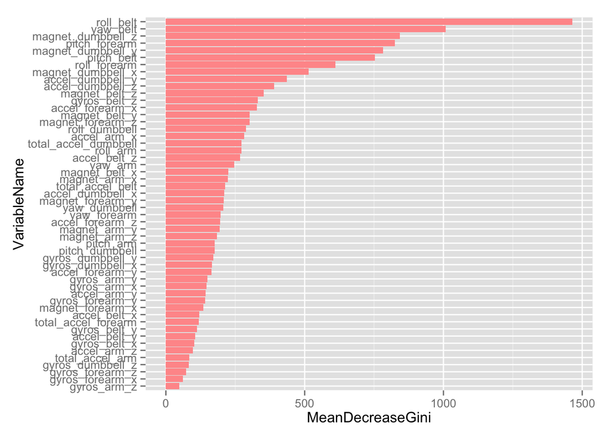

Figure 1: The Random Forest predictors sorted by the importance measured by mean decrease of Gini impurity.

## Cross-validation

A K-fold cross validation (k=10) was performed to measure the accuracy of the model. Table 1 shows the confusion matrix from the K-fold cross validation. The overall accuracy was 98.47% (or estimated error rate of 1.53%).

Table 1: Confusion matrix from the K-fold Cross Validation (k=10)

|  | Actual: A | B | C | D | E |
| --- | --- | --- | --- | --- | --- |
| **Predicted: A** | 5526 | 42 | 8 | 0 | 0 |
| **B** | 35 | 3683 | 35 | 6 | 15 |
| **C** | 13 | 52 | 3359 | 31 | 5 |
| **D** | 5 | 18 | 16 | 3175 | 9 |
| **E** | 1 | 2 | 4 | 4 | 3578 |

### Expected out of sample error

The high accuracy result from K-fold cross validation did not require further search of the models. Using the 10 chosen predictors, the final model was created from the entire training data set.

### Notes on performance considerations

The model was built with R version 3.1.2 (2014-10-31) on x86_64-apple-darwin13.4.0 (64-bit). The hardware was an Apple MacBook Pro with 2.4GHz Intel Core i7 CPU with 8GB 1333 MHz DDR3 RAM.

With the order of magnitude smaller number of predictors than the initial model, it took only 0.44 seconds of elapsed time to build the model.

It should also be noted that I found running caret package with rf option <sup>caret</sup> to be significantly slower than directly running randomForest package. With a similar reason, K-fold validation was coded by authors instead of using rfcv function from randomForest package. See the source code <sup>source</sup> for details of the implementation.

## Result

The classification result of the testing data set <sup>submission</sup> was B, A, B, A, A, E, D, B, A, A, B, C, B, A, E, E, A, B, B, and B for the 20 cases in the order, and they were validated to be all correct.

### References and notes

- [source] The R source code produced the analysis and this report is available from [github page](https://github.com/daigotanaka/practical-ml-final-project/blame/master/practical-ml-final-project.Rmd) [^]
- [Velloso2013] Velloso, E.; Bulling, A.; Gellersen, H.; Ugulino, W.; Fuks, H. Qualitative Activity Recognition of Weight Lifting Exercises. Proceedings of 4th International Conference in Cooperation with SIGCHI (Augmented Human ’13) . Stuttgart, Germany: ACM SIGCHI, 2013. [^]
- [dataset] A dataset was created for the Coursera Practical Machine Learning class by modifying the original dataset. [^]
- [factors] randomForest package of R cannot handle the factor variable with over 53 levels. [^]
- [caret] [Random Forest Models - The caret Package](http://topepo.github.io/caret/Random_Forest.html) [^]
- [submission] The actual Classes were not known before the submission of the model prediction to the course evaluation server. [^]